# Lab: Non-linearity

## GAM Model Analysis and Conclusions

1. Analysis of the Effect of Room. Board (Room and Board Fees) on Outstate Tuition According to the GAM model, the relationship between Room. Board and Outstate tuition is almost perfectly linear as the cost of Room. Board increases, and so does the Outstate tuition. The estimated degrees of freedom suggest the variable has a linear effect (edf = 1.271), albeit with minor non-linear distortions. Moreover, this variable’s impact on Outstate tuition is significant as shown by the extremely low p-value (p < 2e-16).
2. Analysis of the Effect of Enroll (Number of Enrolled Students) on Outstate Tuition The enrolling effect on Outstate tuition is apparent in its nonlinear behavior. The fit curve shows that capitation grants for smaller schools (lower enrollment values) have higher associated costs. With higher enrollment levels, tuition fees begin to decrease before leveling off. This may be the combination of having lower funds available in smaller private institutions and high pupil premium benefits in larger ones. The estimated degrees of freedom (edf = 2.166) support the claim of the variable having a non-linear effect, which is also true given the very low p-value.
3. Effect of Top10perc (Percentage of Freshmen from the Top 10% of Their High School Class) on Outstate Tuition Top10perc variable has a strong non-linear relationship with Outstate tuition. The fitted smoothing curve shows that the increase in top-performing students directly correlates with increased tuition fees. This phenomenon indicates that schools with a more significant concentration of brilliant students tend to capture a better reputation and, hence, can impose higher fees. The estimated degrees of freedom (edf = 1.997) and the extremely small p-value prove the statistical significance of this relationship.
4. Evaluation of the Model as a Whole The adjusted R-squared 0.578 suggests that the model captures about 57.8% of the variation in Outstate tuition. The deviance explained 58.2% shows that the predictors accounted well for the variance although other reasons could be causing the tuition fee. The smoothing terms indicate that non-linear factors are important when considering out-of-state tuition costs.
3. Evaluate the model obtained on the test set, and explain the results obtained.

```r
# Predict on test data
test_predictions <- predict(gam_model, newdata = test_data)

# Calculate RMSE
rmse <- sqrt(mean((test_data$Outstate - test_predictions)^2))

# Calculate R-squared
ss_total <- sum((test_data$Outstate - mean(test_data$Outstate))^2)
ss_residual <- sum((test_data$Outstate - test_predictions)^2)
r_squared <- 1 - (ss_residual / ss_total)

# Print results
print(paste("Test RMSE:", round(rmse, 2)))
```

```
[1] "Test RMSE: 2328.39"
```

```r
print(paste("Test R-squared:", round(r_squared, 4)))
```

```
[1] "Test R-squared: 0.6706"
```

1. Test RMSE = 2328.39 This RMSE value indicates that the model’s predictions for out-of-state tuition error by 2328.39 on average. The performance is clearly low since the value is almost one at 2328.39, which is the RMSE deviation itself. From this value, it can be inferred that the average deviation of out-of-state tuition predictions made by the model from the actual values lies in a boundary of approximately 2328.39. A lower RMSE would mean a higher model performance, making the model incredible at making predictions.
2. Test R-squared = 0.6706 Out-of-state tuition, where the model captures variation that is explained on its own by the model, is a lower average of 67.06%. This indicates a moderately good fit for certain patterns, making it capture. However, it also states that the model does not capture complex non-linear patterns. It still captures 32.94% of the unexplained variation, which gives a sense the model is still trying to find patterns along with predictors.
4. For which variables, if any, is there evidence of a non-linear relationship with the response? (make scatterplots of the response against the five numerical predictors.)

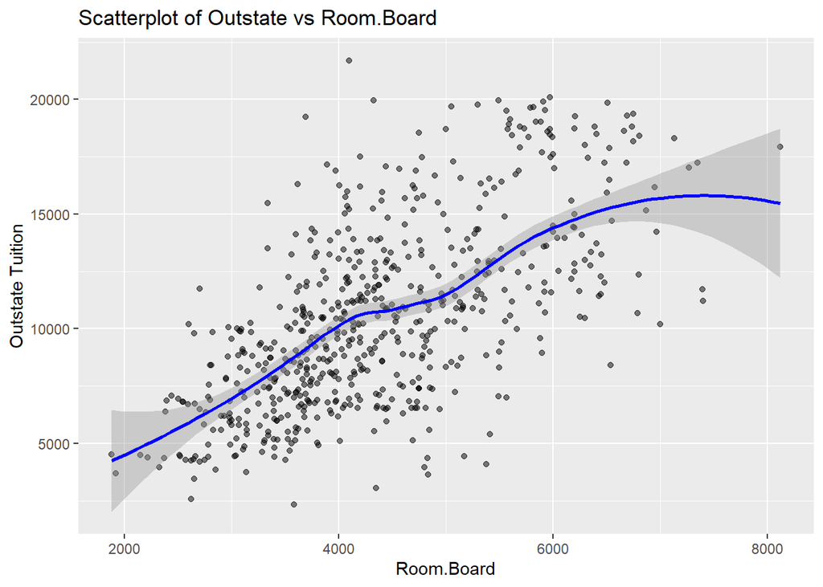

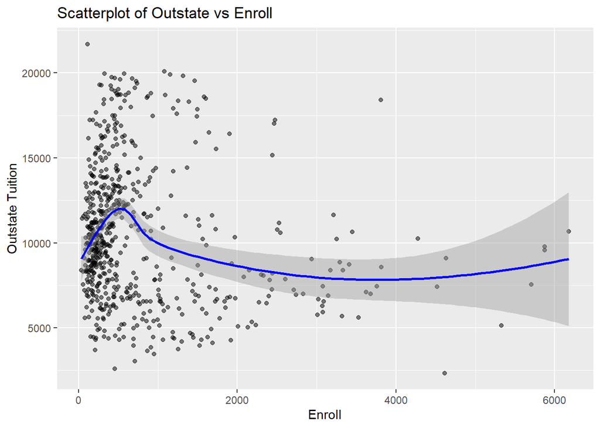

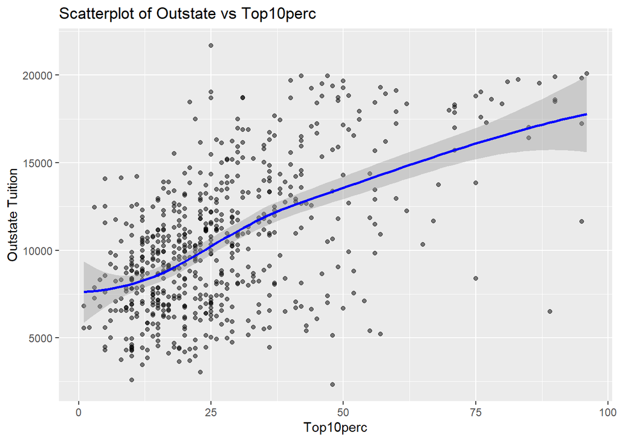

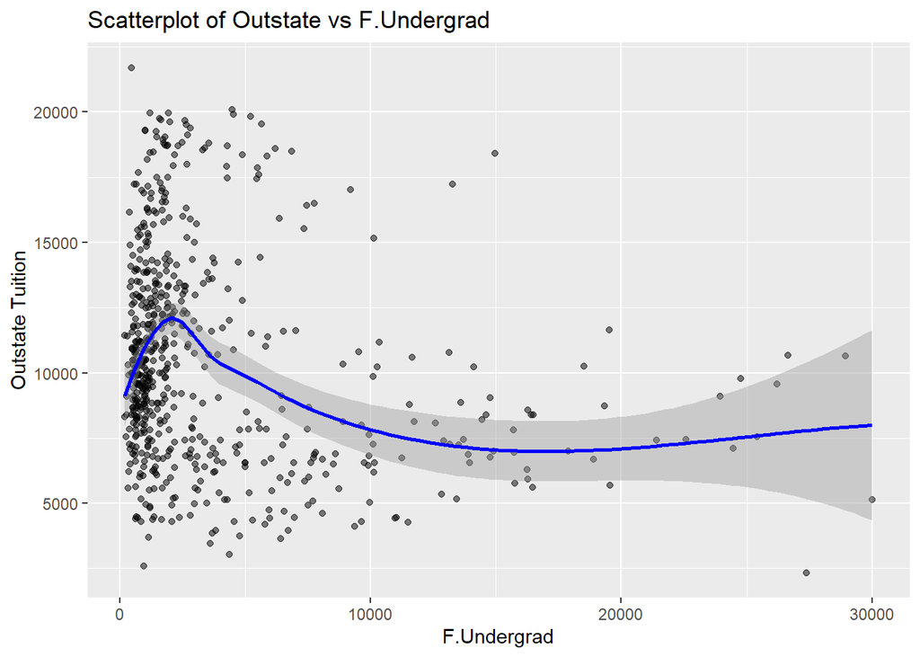

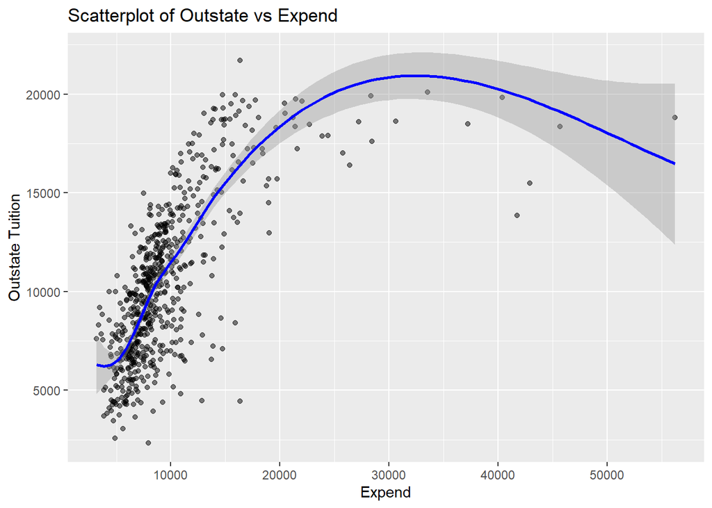

```r
# Load ggplot2 for visualization
library(ggplot2)

# Define selected numerical predictors
selected_vars <- c("Room.Board", "Enroll", "Top10perc", "F.Undergrad", "Expend")

# Create scatterplots with a smoothing curve using updated ggplot2 syntax
for (var in selected_vars) {
  print(ggplot(train_data, aes(x = .data[[var]], y = Outstate)) +
    geom_point(alpha = 0.5) +  # Scatterplot points
    geom_smooth(method = "loess", color = "blue") +  # Smooth curve to show trend
    labs(title = paste("Scatterplot of Outstate vs", var),
         x = var, y = "Outstate Tuition"))
}
```

1. Room. Board: Tuition grows with Room. Board, but the growth is lesser as the value increases, indicating a diminishing return effect.
2. Enroll: An inverted U hypothesized pattern indicates that lesser-known colleges tend to charge higher tuition, while well-known colleges tend to have lower tuition.
3. F. Undergrad: Enroll trend where a lesser undergraduate population corresponds to higher tuition and a more significant population demonstrates the lessening effect.
4. Expend: Tuition grows with expenditure per student but flattens at the higher spending levels.

All these relationships confirm the patterns and explain the primary reason, which is the non-linear modeling approach like GAMs.